# Decision Tree

Ефременко Влада

2023-11-09

```r
library(tree)
library(mlbench)
library(maptree)
library(DAAG)
library(e1071)
library(ggplot2)
library(gridExtra)
library(dplyr)
```

# Задание 1

Загрузите набор данных Glass из пакета “mlbench”. Набор данных (признаки, классы) был изучен в работе «Метод ближайших соседей». Постройте дерево классификации для модели, задаваемой следующей формулой: Type ~ ., дайте интерпретацию полученным результатам. При рисовании дерева используйте параметр cex=0.7 для уменьшения размера текста на рисунке, например, text(bc.tr,cex=0.7) или draw.tree(bc.tr,cex=0.7). Является ли построенное дерево избыточным? Выполните все операции оптимизации дерева.

```r
data("Glass")
head(Glass)
```

```
##        RI    Na   Mg   Al    Si    K   Ca Ba   Fe Type
## 1 1.52101 13.64 4.49 1.10 71.78 0.06 8.75  0 0.00    1
## 2 1.51761 13.89 3.60 1.36 72.73 0.48 7.83  0 0.00    1
## 3 1.51618 13.53 3.55 1.54 72.99 0.39 7.78  0 0.00    1
## 4 1.51766 13.21 3.69 1.29 72.61 0.57 8.22  0 0.00    1
## 5 1.51742 13.27 3.62 1.24 73.08 0.55 8.07  0 0.00    1
## 6 1.51596 12.79 3.61 1.62 72.97 0.64 8.07  0 0.26    1
```

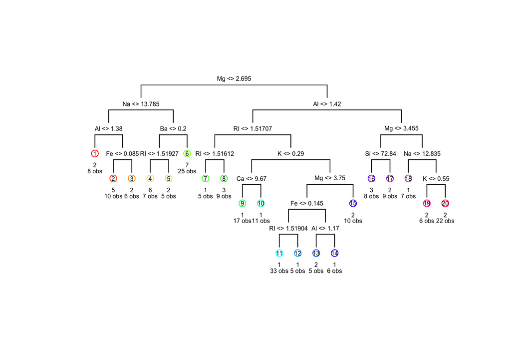

```r
model <- tree(Type ~ ., Glass)
draw.tree(model, cex=0.5)
```

## Интерпретация полученных результатов:

Из визуализации дерева решений видно, что оно является избыточным, так как есть разветвления, где выбор происходит между одинаковыми классами, например, 19-20.

```r
model
```

```
## node), split, n, deviance, yval, (yprob)
##       * denotes terminal node
##
##   1) root 214 645.700 2 ( 0.327103 0.355140 0.079439 0.060748 0.042056 0.135514 )
##     2) Mg < 2.695 61 159.200 7 ( 0.000000 0.213115 0.000000 0.213115 0.147541 0.426230 )
##       4) Na < 13.785 24  40.160 5 ( 0.000000 0.458333 0.000000 0.500000 0.000000 0.041667 )
##         8) Al < 1.38 8   6.028 2 ( 0.000000 0.875000 0.000000 0.000000 0.000000 0.125000 ) *
##         9) Al > 1.38 16  17.990 5 ( 0.000000 0.250000 0.000000 0.750000 0.000000 0.000000 )
##          18) Fe < 0.085 10   0.000 5 ( 0.000000 0.000000 0.000000 1.000000 0.000000 0.000000 ) *
##          19) Fe > 0.085 6   7.638 2 ( 0.000000 0.666667 0.000000 0.333333 0.000000 0.000000 ) *
##       5) Na > 13.785 37  63.940 7 ( 0.000000 0.054054 0.000000 0.027027 0.243243 0.675676 )
##        10) Ba < 0.2 12  17.320 6 ( 0.000000 0.166667 0.000000 0.000000 0.750000 0.083333 )
##          20) RI < 1.51927 7   0.000 6 ( 0.000000 0.000000 0.000000 0.000000 1.000000 0.000000 ) *
##          21) RI > 1.51927 5  10.550 2 ( 0.000000 0.400000 0.000000 0.000000 0.400000 0.200000 ) *
##        11) Ba > 0.2 25   8.397 7 ( 0.000000 0.000000 0.000000 0.040000 0.000000 0.960000 ) *
##     3) Mg > 2.695 153 319.600 1 ( 0.457516 0.411765 0.111111 0.000000 0.000000 0.019608 )
##       6) Al < 1.42 101 189.000 1 ( 0.633663 0.227723 0.128713 0.000000 0.000000 0.009901 )
##        12) RI < 1.51707 14  28.970 3 ( 0.214286 0.285714 0.500000 0.000000 0.000000 0.000000 )
##          24) RI < 1.51612 5   6.730 1 ( 0.600000 0.000000 0.400000 0.000000 0.000000 0.000000 ) *
##          25) RI > 1.51612 9  12.370 3 ( 0.000000 0.444444 0.555556 0.000000 0.000000 0.000000 ) *
##        13) RI > 1.51707 87 142.200 1 ( 0.701149 0.218391 0.068966 0.000000 0.000000 0.011494 )
##          26) K < 0.29 28  42.500 1 ( 0.714286 0.071429 0.214286 0.000000 0.000000 0.000000 )
##            52) Ca < 9.67 17  22.070 1 ( 0.647059 0.000000 0.352941 0.000000 0.000000 0.000000 ) *
##            53) Ca > 9.67 11  10.430 1 ( 0.818182 0.181818 0.000000 0.000000 0.000000 0.000000 ) *
##          27) K > 0.29 59  80.310 1 ( 0.694915 0.288136 0.000000 0.000000 0.000000 0.016949 )
##            54) Mg < 3.75 49  49.640 1 ( 0.836735 0.142857 0.000000 0.000000 0.000000 0.020408 )
##             108) Fe < 0.145 38  18.440 1 ( 0.947368 0.026316 0.000000 0.000000 0.000000 0.026316 )
##               216) RI < 1.51904 33   0.000 1 ( 1.000000 0.000000 0.000000 0.000000 0.000000 0.000000 ) *
##               217) RI > 1.51904 5   9.503 1 ( 0.600000 0.200000 0.000000 0.000000 0.000000 0.200000 ) *
##             109) Fe > 0.145 11  15.160 2 ( 0.454545 0.545455 0.000000 0.000000 0.000000 0.000000 )
##               218) Al < 1.17 5   0.000 2 ( 0.000000 1.000000 0.000000 0.000000 0.000000 0.000000 ) *
##               219) Al > 1.17 6   5.407 1 ( 0.833333 0.166667 0.000000 0.000000 0.000000 0.000000 ) *
##            55) Mg > 3.75 10   0.000 2 ( 0.000000 1.000000 0.000000 0.000000 0.000000 0.000000 ) *
##       7) Al > 1.42 52  80.450 2 ( 0.115385 0.769231 0.076923 0.000000 0.000000 0.038462 )
##        14) Mg < 3.455 17  29.710 2 ( 0.000000 0.647059 0.235294 0.000000 0.000000 0.117647 )
##          28) Si < 72.84 8  16.640 3 ( 0.000000 0.250000 0.500000 0.000000 0.000000 0.250000 ) *
##          29) Si > 72.84 9   0.000 2 ( 0.000000 1.000000 0.000000 0.000000 0.000000 0.000000 ) *
##        15) Mg > 3.455 35  32.070 2 ( 0.171429 0.828571 0.000000 0.000000 0.000000 0.000000 )
##          30) Na < 12.835 7   9.561 1 ( 0.571429 0.428571 0.000000 0.000000 0.000000 0.000000 ) *
##          31) Na > 12.835 28  14.410 2 ( 0.071429 0.928571 0.000000 0.000000 0.000000 0.000000 )
##            62) K < 0.55 6   7.638 2 ( 0.333333 0.666667 0.000000 0.000000 0.000000 0.000000 ) *
##            63) K > 0.55 22   0.000 2 ( 0.000000 1.000000 0.000000 0.000000 0.000000 0.000000 ) *
```

Выполним оптимизацию дерева:

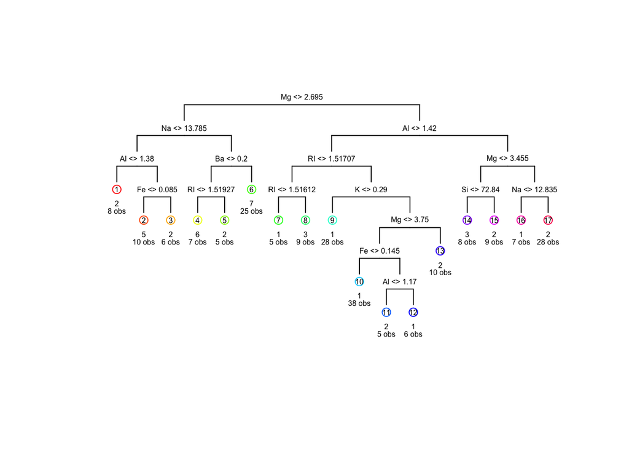

```r
opt_model <- snip.tree(model, nodes = c(26, 108, 31))
draw.tree(opt_model, cex=0.5)
```

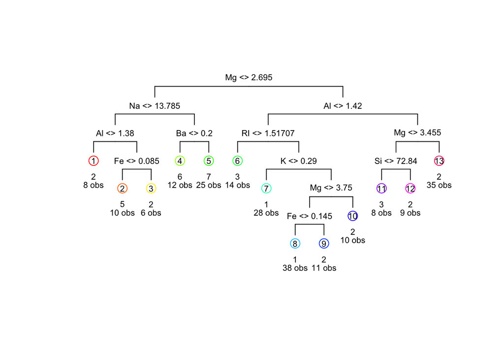

```r
pruned_model <- prune.tree(opt_model, k=10)
draw.tree(pruned_model, cex=0.7)
```

Удалили избыточные ветви.

# Задание 2

Загрузите набор данных spam7 из пакета DAAG. Постройте дерево классификации для модели, задаваемой следующей формулой: yesno ~., дайте интерпретацию полученным результатам. Запустите процедуру “cost-complexity prunning” с выбором параметра k по умолчанию, method = ’misclass’, выведите полученную последовательность деревьев. Какое из полученных деревьев, на Ваш взгляд, является оптимальным? Объясните свой выбор.

```r
data(spam7)
head(spam7)
```

```
##   crl.tot dollar  bang money n000 make yesno
## 1     278  0.000 0.778  0.00 0.00 0.00     y
## 2    1028  0.180 0.372  0.43 0.43 0.21     y
## 3    2259  0.184 0.276  0.06 1.16 0.06     y
## 4     191  0.000 0.137  0.00 0.00 0.00     y
## 5     191  0.000 0.135  0.00 0.00 0.00     y
## 6      54  0.000 0.000  0.00 0.00 0.00     y
```

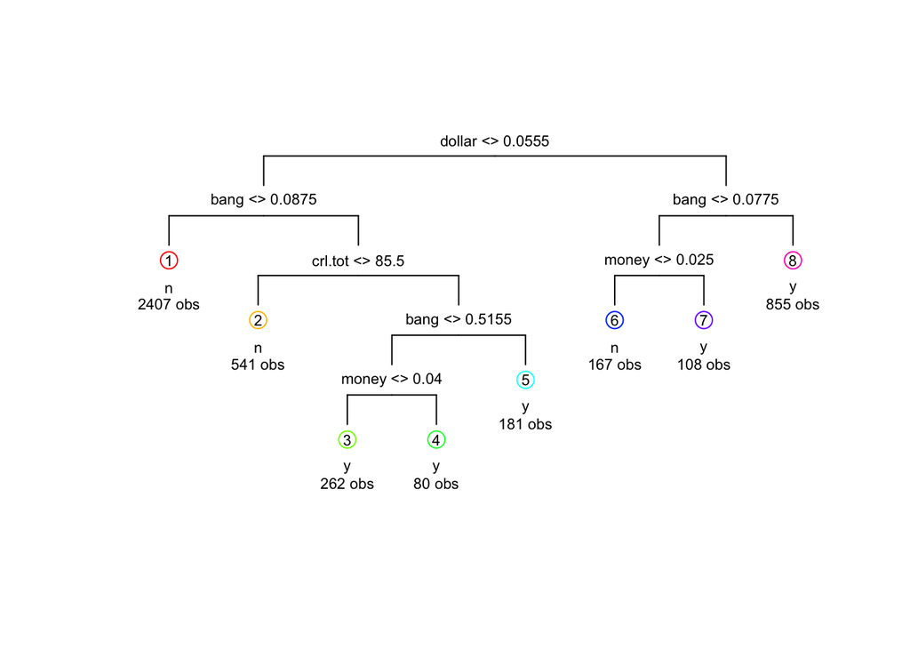

```r
model <- tree(yesno ~ ., spam7)
draw.tree(model, cex=0.7)
```

## Интерпретация полученных результатов:

Из визуализации дерева решений видно, что оно является избыточным, так как есть разветвления, где выбор происходит между одинаковыми классами, например, 3,4,5. Запустим процедуру “cost-complexity prunning”:

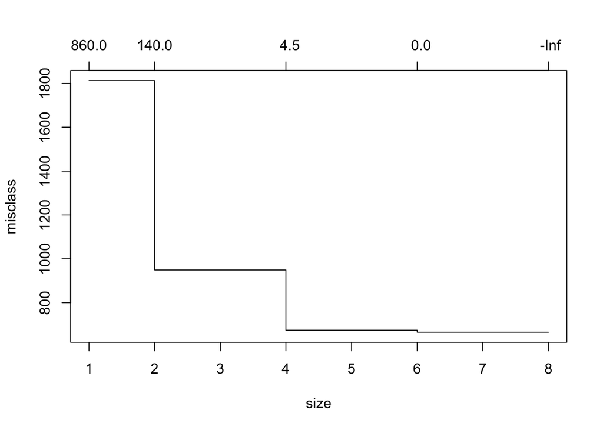

```r
pruned_model <- prune.misclass(model)
plot(pruned_model)
```

```r
pruned_model
```

```
## $size
## [1] 8 6 4 2 1
##
## $dev
## [1]  665  665  674  949 1813
##
## $k
## [1]  -Inf   0.0   4.5 137.5 864.0
##
## $method
## [1] "misclass"
##
## attr(,"class")
## [1] "prune"         "tree.sequence"
```

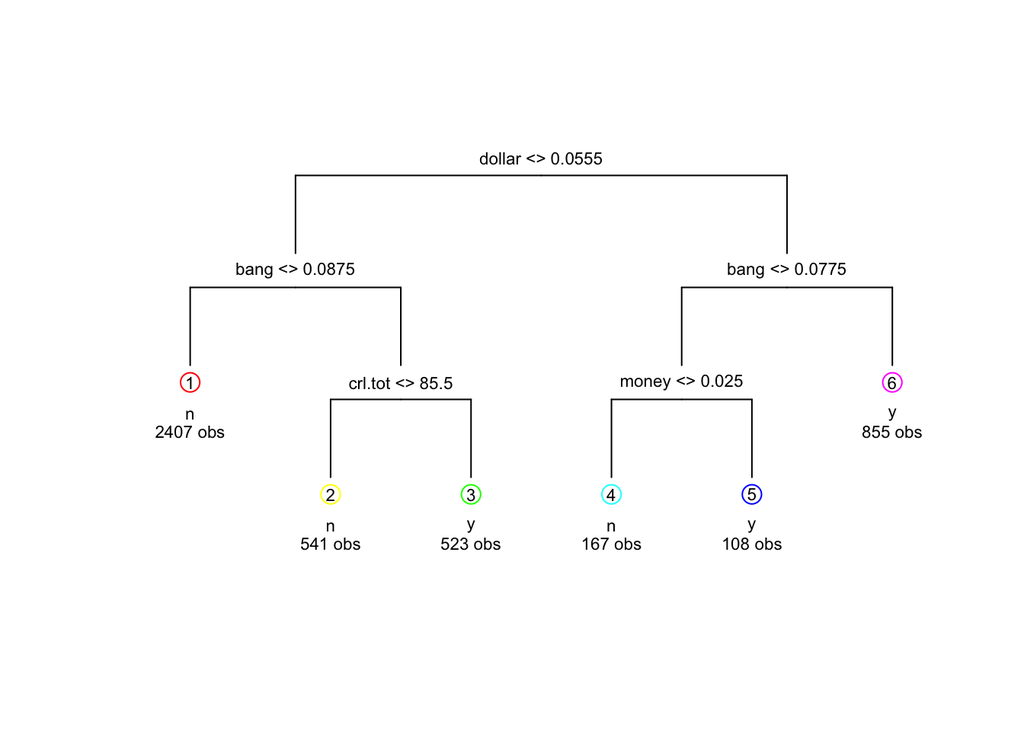

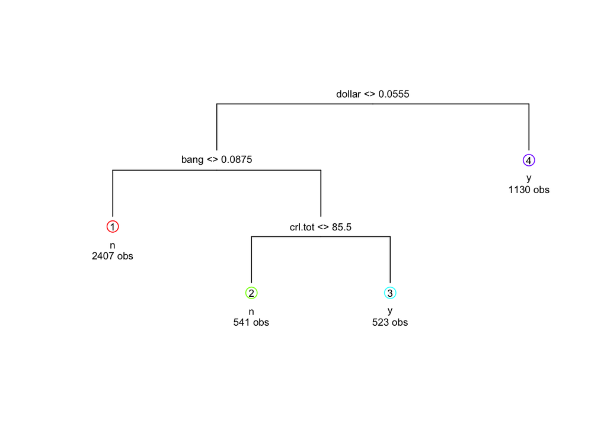

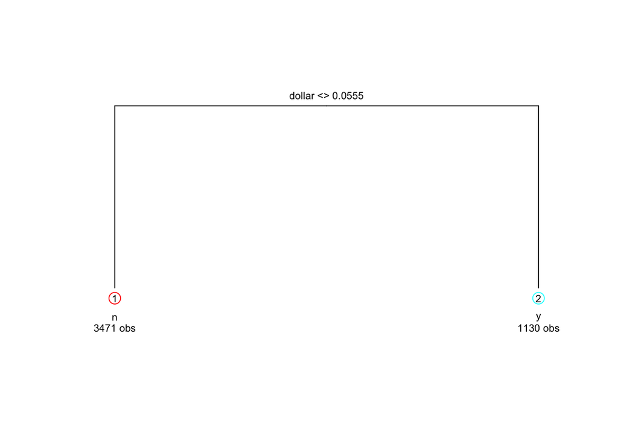

```r
for(k in c(0.0, 4.5, 137.5)){
  draw.tree(prune.tree(model, k = k, method = 'misclass'), cex=0.7)
}
```

## Какое из полученных деревьев является оптимальным?

Дерево, полученное после выполнения процедуры с параметром k=0 уже выглядит оптимальным, так как в нем нет избыточности, а также сохранены значимые разветвления.

# Задание 3

Загрузите набор данных nsw74psid1 из пакета DAAG. Постройте регрессионное дерево для модели, задаваемой следующей формулой: re78 ~.. Постройте регрессионную модель и SVM-регрессию для данной формулы. Сравните качество построенных моделей, выберите оптимальную модель и объясните свой выбор.

```r
data(nsw74psid1)
head(nsw74psid1)
```

```
##   trt age educ black hisp marr nodeg re74 re75 re78
## 1   0  47   12     0    0    0     0    0    0    0
## 2   0  50   12     1    0    1     0    0    0    0
## 3   0  44   12     0    0    0     0    0    0    0
## 4   0  28   12     1    0    1     0    0    0    0
## 5   0  54   12     0    0    1     0    0    0    0
## 6   0  55   12     0    1    1     0    0    0    0
```

```r
n <- dim(nsw74psid1)[1]

nsw74psid1_rand <- nsw74psid1[order(runif(n)),]
df_train <- nsw74psid1_rand[1:as.integer(n*0.8),]
df_test <- nsw74psid1_rand[(as.integer(n*0.8)+1):n,]
```

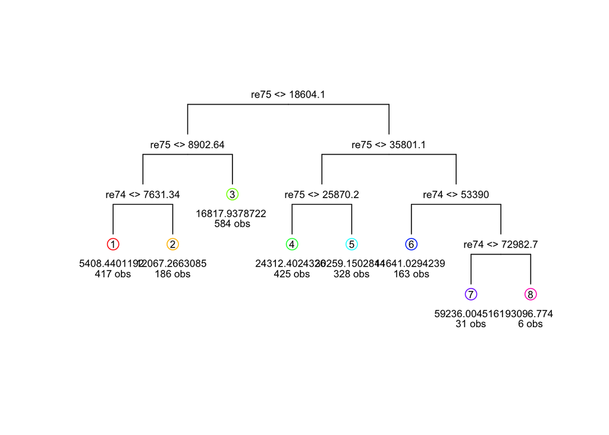

```r
model_tree <- tree(re78 ~., df_train)
model_svm <- svm(df_train[-10], df_train$re78, type="eps-regression", cost=1, eps=0.25)
draw.tree(model_tree, cex=0.7)
```

```r
predict_tree <- predict(model_tree, df_test[-10])
predict_svm <- predict(model_svm, df_test[-10])

mist_tree <- sd(df_test$re78 - predict_tree)
mist_svm <- sd(df_test$re78 - predict_svm)

print("Ошибка на тестовых данных, полученная деревом решений: ")
```

```
## [1] "Ошибка на тестовых данных, полученная деревом решений: "
```

```r
mist_tree
```

```
## [1] 10516.99
```

```r
print("Ошибка на тестовых данных, полученная SVM: ")
```

```
## [1] "Ошибка на тестовых данных, полученная SVM: "
```

```r
mist_svm
```

```
## [1] 10214.42
```

Ошибка на тестовой выборке c использованием модели SVM меньше по сравнению с деревом решений, поэтому она оптимальнее.

# Задание 4

Загрузите набор данных Lenses Data Set из файла Lenses.txt: 3 класса (последний столбец): 1 : пациенту следует носить жесткие контактные линзы, 2 : пациенту следует носить мягкие контактные линзы, 3 : пациенту не следует носить контактные линзы. Признаки (категориальные): 1. возраст пациента: (1) молодой, (2) предстарческая дальнозоркость, (3) старческая дальнозоркость 2. состояние зрения: (1) близорукий, (2) дальнозоркий 3. астигматизм: (1) нет, (2) да 4. состояние слезы: (1) сокращенная, (2) нормальная Постройте дерево решений. Какие линзы надо носить при предстарческой дальнозоркости, близорукости, при наличии астигматизма и сокращенной слезы?

```r
lenses <- read.table("Lenses.txt")
lenses <- lenses[, -1]
lenses$V6 <- as.factor(lenses$V6)
head(lenses)
```

```
##   V2 V3 V4 V5 V6
## 1  1  1  1  1  3
## 2  1  1  1  2  2
## 3  1  1  2  1  3
## 4  1  1  2  2  1
## 5  1  2  1  1  3
## 6  1  2  1  2  2
```

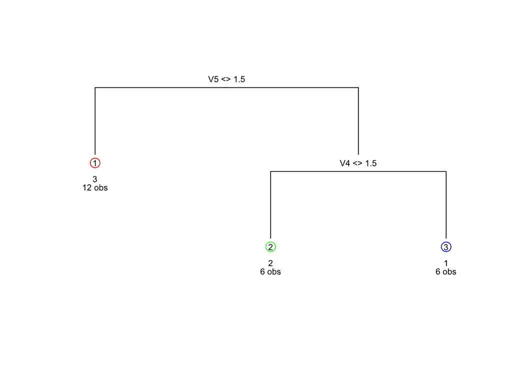

```r
model <- tree(V6 ~., lenses)
draw.tree(model, cex=0.7)
```

```r
data_test <- data.frame(V2=2, V3=1, V4=2, V5=1)
prediction <- predict(model, data_test)
cat("Предсказанный класс:", prediction,"\n")
```

```
## Предсказанный класс: 0 0 1
```

# Задание 5

Постройте дерево решений для обучающего множества Glass, данные которого характеризуются 10-ю признаками: 1. Id number: 1 to 214; 2. RI: показатель преломления; 3. Na: сода (процент содержания в соотвествующем оксиде); 4. Mg; 5. Al; 6. Si; 7. K; 8. Ca; 9. Ba; 10. Fe. Классы характеризуют тип стекла: (1) окна зданий, плавильная обработка (2) окна зданий, не плавильная обработка (3) автомобильные окна, плавильная обработка (4) автомобильные окна, не плавильная обработка (нет в базе) (5) контейнеры (6) посуда (7) фары Посмотрите заголовки признаков и классов. Перед построением классификатора необходимо также удалить первый признак Id number, который не несет никакой информационной нагрузки. Это выполняется командой glass <- glass[,-1]. Определите, к какому типу стекла относится экземпляр с характеристиками RI =1.516 Na =11.7 Mg =1.01 Al =1.19 Si =72.59 K=0.43 Ca =11.44 Ba =0.02 Fe =0.1

```r
data("Glass")
head(Glass)
```

```
##        RI    Na   Mg   Al    Si    K   Ca Ba   Fe Type
## 1 1.52101 13.64 4.49 1.10 71.78 0.06 8.75  0 0.00    1
## 2 1.51761 13.89 3.60 1.36 72.73 0.48 7.83  0 0.00    1
## 3 1.51618 13.53 3.55 1.54 72.99 0.39 7.78  0 0.00    1
## 4 1.51766 13.21 3.69 1.29 72.61 0.57 8.22  0 0.00    1
## 5 1.51742 13.27 3.62 1.24 73.08 0.55 8.07  0 0.00    1
## 6 1.51596 12.79 3.61 1.62 72.97 0.64 8.07  0 0.26    1
```

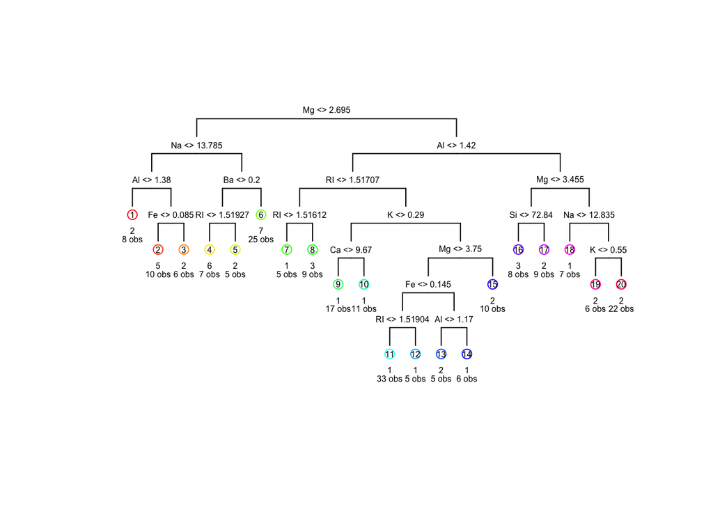

```r
model <- tree(Type ~ ., Glass)
draw.tree(model, cex=0.5)
```

```r
data_test <- data.frame(RI=1.516, Na =11.7, Mg =1.01, Al =1.19, Si =72.59, K=0.43, Ca =11.44, Ba =0.02, Fe =0.1)
prediction <- predict(model, data_test)
cat("Предсказанный класс:\n")
```

```
## Предсказанный класс:
```

```r
prediction
```

```
##   1     2 3 5 6     7
## 1 0 0.875 0 0 0 0.125
```

С вероятностью 0.875 экземпляр относится к классу (2) окна зданий, не плавильная обработка.

# Задание 6

Для построения классификатора используйте заранее сгенерированные обучающие и тестовые выборки, хранящиеся в файлах svmdata4.txt, svmdata4test.txt.

```r
train_data <- read.table("svmdata4.txt",stringsAsFactors = TRUE)
test_data <- read.table("svmdata4test.txt",stringsAsFactors = TRUE)
```

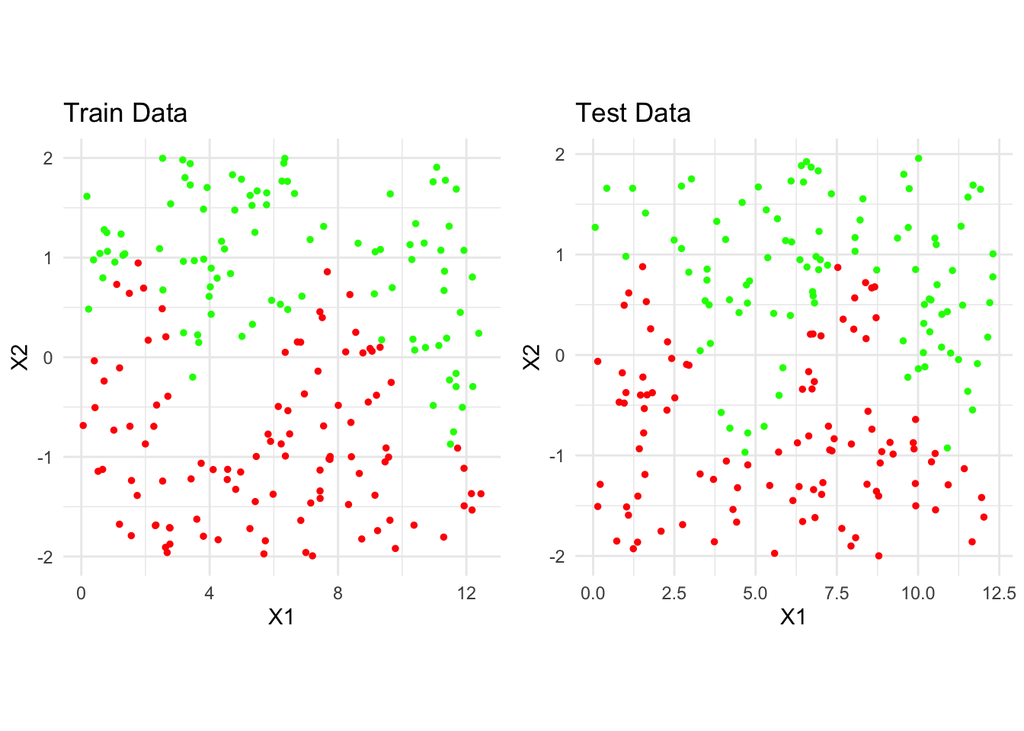

```r
# График для обучающей выборки
plot_train <- ggplot(train_data, aes(x = X1, y = X2, color = factor(Colors))) +
  geom_point(size = 1) +
  labs(x = "X1", y = "X2", title = "Train Data") +
  scale_color_manual(values = c("red" = "red", "green" = "green")) +
  theme_minimal() +
  theme(aspect.ratio = 1, legend.position = "none")

# График для тестовой выборки
plot_test <- ggplot(test_data, aes(x = X1, y = X2, color = factor(Colors))) +
  geom_point(size = 1) +
  labs(x = "X1", y = "X2", title = "Test Data") +
  scale_color_manual(values = c("red" = "red", "green" = "green")) +
  theme_minimal() +
  theme(aspect.ratio = 1, legend.position = "none")

grid.arrange(plot_train, plot_test, ncol = 2)
```

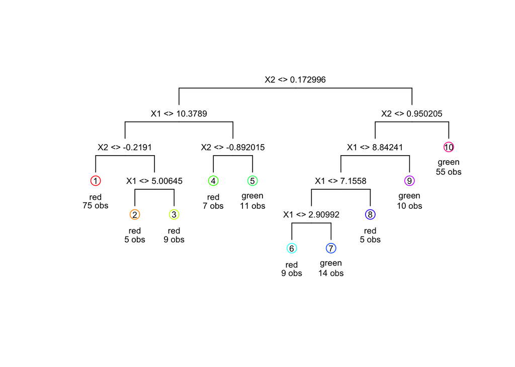

```r
model <- tree(Colors ~ ., train_data)
draw.tree(model, cex=0.7)
```

```r
predict_tree <- predict(model, test_data[-3])

predicted_classes <- ifelse(predict_tree[, "red"] > predict_tree[, "green"], "red", "green")

conf_matrix <- table(test_data$Colors, predicted_classes)
accuracy <- sum(diag(conf_matrix)) / sum(conf_matrix)

cat("Accuracy:", accuracy, "\n")
```

```
## Accuracy: 0.9
```

# Задание 7

Разработать классификатор на основе дерева решений для данных Титаник (Titanic dataset) - https://www.kaggle.com/c/titanic Исходные обучающие данные для классификации – в файле Titanic_train.csv Данные для тестирования – в файле Titanic_test.csv

```r
train_data <- read.csv("train.csv",stringsAsFactors = TRUE)
test_data <- read.csv("test.csv",stringsAsFactors = TRUE)
```

```r
# Подготовка данных
preprocess_data <- function(data) {
  # Удаление столбцов
  columns_to_drop <- c("Name", "Ticket", "Cabin", "PassengerId")
  data <- data[, !(names(data) %in% columns_to_drop)]

  # Заполнение пропущенных значений
  data <- data %>%
    mutate(Age = ifelse(is.na(Age), mean(Age, na.rm = TRUE), Age),
           Fare = ifelse(is.na(Fare), mean(Fare, na.rm = TRUE), Fare),
           Embarked = ifelse(is.na(Embarked), levels(Embarked)[which.max(table(Embarked))], Embarked),
           Sex = ifelse(is.na(Sex), levels(Sex)[which.max(table(Sex))], Sex))

  # Преобразование категориальных переменных
  categorical_features <- c("Sex", "Embarked")

  for (feature in categorical_features) {
    data[[feature]] <- as.factor(data[[feature]])
  }
  return(data)
}
```

```r
train_data_preprocessed <- preprocess_data(train_data)
train_data_preprocessed$Survived <- as.factor(train_data_preprocessed$Survived)
head(train_data_preprocessed)
```

```
##   Survived Pclass Sex      Age SibSp Parch    Fare Embarked
## 1        0      3   2 22.00000     1     0  7.2500        4
## 2        1      1   1 38.00000     1     0 71.2833        2
## 3        1      3   1 26.00000     0     0  7.9250        4
## 4        1      1   1 35.00000     1     0 53.1000        4
## 5        0      3   2 35.00000     0     0  8.0500        4
## 6        0      3   2 29.69912     0     0  8.4583        3
```

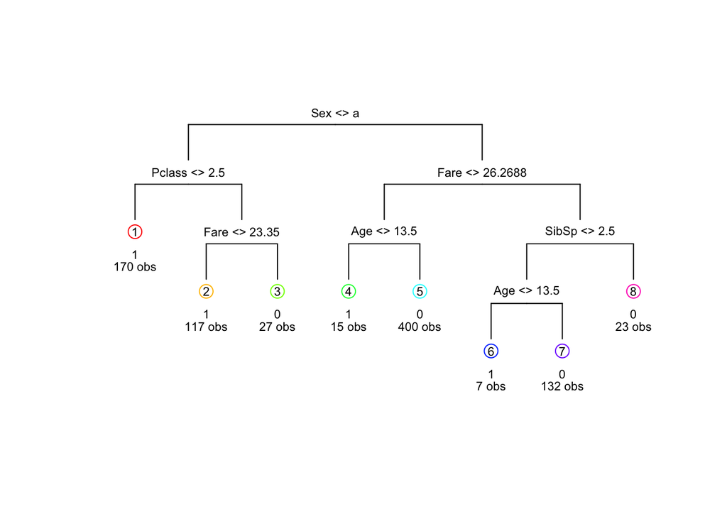

```r
model <- tree(Survived ~., train_data_preprocessed)
draw.tree(model, cex=0.7)
```

```r
test_data_preprocessed <- preprocess_data(test_data)
predict_tree <- predict(model, test_data_preprocessed)

predicted_classes <- ifelse(predict_tree[, '1'] > predict_tree[, '0'], 1, 0)
class_counts <- table(predicted_classes)

cat("Количество выживших: ", class_counts[1])
```

[output not shown]

```r
cat("Количество погибших: ", class_counts[2])
```

[output not shown]